# Rcourse lecture2

2023-09-13

## Data handling with Tidyverse

Today we will learn to:

- Import and export data
- Clean and reformat data
- Filter data
- Perform simple data mining on our datasets

The package that we are going to use is called tidyverse.

You can install it with:

```r
install.packages('tidyverse')
```

## What is tidyverse?

The tidyverse is a coherent system of packages for data manipulation, exploration and visualization that share a common design philosophy.

[figure not shown]

We will see a few commands from **tibble** and several from **dplyr**.

## Tidy data

**Tidy data** is a standard way of mapping the meaning of a dataset to its structure.

In **tidy data**:

- Every column is a variable.
- Every row is an observation.
- Every cell is a single value.

Having **tidy data** can avoid problems in the future.

You can tidy your data directly from R or from excel.

## Steps in data handling 1

- **Import data**
- Clean data
- Select and filter data
- Analyze data
- Export data

## Let’s import some data!

The most common format for data is tables. In R, table objects are called dataframes. Tidyverse has a specific type of dataframes, called **tibbles**. The most common command to import **tibbles** is **read_tsv()**. Remember, before starting to work, to activate the **tidyverse** package with the **library(tidyverse)** command.

```r
data <- read_tsv('dogs.txt', show_col_types = FALSE)
head(data, n=5)
```

```
## # A tibble: 5 x 4
##   Name           Breed        Weight_kg OwnerCity
##   <chr>          <chr>        <chr>     <chr>
## 1 Spruzzolo      Sausage dog  na        Edo_Turin
## 2 Nala           Mastiff      <NA>      Miguel_Barcelona
## 3 Milou          Mastiff      138       Allison_Vancouver
## 4 Mr Fluffypants Mastiff      110       Julia_Uppsala
## 5 Colonel        Rough collie 50        Meredith_Birmingham
```

## Let’s import some data!

The command **head** shows the first 6 line of a tibble. The option **n** allows you to specify a different number.

```r
data <- read_tsv('dogs.txt', show_col_types = FALSE)
head(data)
```

```
## # A tibble: 6 x 4
##   Name           Breed        Weight_kg OwnerCity
##   <chr>          <chr>        <chr>     <chr>
## 1 Spruzzolo      Sausage dog  na        Edo_Turin
## 2 Nala           Mastiff      <NA>      Miguel_Barcelona
## 3 Milou          Mastiff      138       Allison_Vancouver
## 4 Mr Fluffypants Mastiff      110       Julia_Uppsala
## 5 Colonel        Rough collie 50        Meredith_Birmingham
## 6 Aurelion       Sausage dog  10        Marcus_Stockholm
```

## Let’s import some data!

The commands **nrow**, **ncol** and **dim** allow you to see the dimension of your tibble

```r
data <- read_tsv('dogs.txt', show_col_types = FALSE)
ncol(data)
```

```
## [1] 4
```

```r
nrow(data)
```

```
## [1] 14
```

```r
dim(data)
```

```
## [1] 14  4
```

## You can import directly from excel

You need the package readxl, also part of tidyverse

```r
library(readxl)
data <- read_excel('dogs.xlsx')
head(data)
```

```
## # A tibble: 6 x 4
##   Name           Breed        Weight_kg OwnerCity
##   <chr>          <chr>        <chr>     <chr>
## 1 Spruzzolo      Sausage dog  na        Edo_Turin
## 2 Nala           Mastiff      NA        Miguel_Barcelona
## 3 Milou          Mastiff      138       Allison_Vancouver
## 4 Mr Fluffypants Mastiff      110       Laura_Uppsala
## 5 Colonel        Rough collie 50        Meredith_Birmingham
## 6 Aurelion       Sausage dog  10        Marcus_Stockholm
```

## You can import directly from tht web

All the files of this lesson are available at: https://raw.githubusercontent.com/mikdur/r-primer/main/lecture2/

For example, to download ‘dogs.txt’, I can use **read_tsv** on https://raw.githubusercontent.com/mikdur/r-primer/main/lecture2/dogs.txt

## You can import directly from tht web

For example, to download ‘dogs.txt’, I can use **read_tsv** on https://raw.githubusercontent.com/mikdur/r-primer/main/lecture2/dogs.txt

```r
library(readxl)
data <- read_tsv('https://raw.githubusercontent.com/mikdur/r-primer/main/lecture2/dogs.txt', show_col_types = FALSE)
head(data)
```

```
## # A tibble: 6 x 4
##   Name           Breed        Weight_kg OwnerCity
##   <chr>          <chr>        <chr>     <chr>
## 1 Spruzzolo      Sausage dog  na        Edo_Turin
## 2 Nala           Mastiff      <NA>      Miguel_Barcelona
## 3 Milou          Mastiff      138       Allison_Vancouver
## 4 Mr Fluffypants Mastiff      110       Laura_Uppsala
## 5 Colonel        Rough collie 50        Meredith_Birmingham
## 6 Aurelion       Sausage dog  10        Marcus_Stockholm
```

## Useful options when importing data

The **na** option allows you to specify which strings indicate absent data

```r
data <- read_tsv('dogs.txt', na = c("", "NA", "na"), show_col_types = FALSE)
head(data, n=5)
```

```
## # A tibble: 5 x 4
##   Name           Breed        Weight_kg OwnerCity
##   <chr>          <chr>            <dbl> <chr>
## 1 Spruzzolo      Sausage dog         NA Edo_Turin
## 2 Nala           Mastiff             NA Miguel_Barcelona
## 3 Milou          Mastiff            138 Allison_Vancouver
## 4 Mr Fluffypants Mastiff            110 Julia_Uppsala
## 5 Colonel        Rough collie        50 Meredith_Birmingham
```

## Useful options when importing data 2

The **comment** option allows you to specify which lines are comments and not contain real data

```r
data <- read_tsv('F_graminearum.gff', show_col_types = FALSE)
head(data, n=5)
```

```
## # A tibble: 5 x 1
##   `##gff-version 3`
##   <chr>
## 1 #!gff-spec-version 1.21
## 2 #!processor NCBI annotwriter
## 3 #!genome-build ASM24013v3
## 4 #!genome-build-accession NCBI_Assembly:GCF_000240135.3
## 5 ##sequence-region NC_026474.1 1 11697295
```

## Useful options when importing data 2

The **comment** option allows you to specify which lines are comments and not contain real data

```r
data <- read_tsv('F_graminearum.gff', comment="#",
                 show_col_types = FALSE)
head(data, n=5)
```

```
## # A tibble: 5 x 9
##   NC_026474.1 RefSeq region   `1` `11697295` ....6 `+`   ....8
##   <chr>       <chr>  <chr>  <dbl>      <dbl> <chr> <chr> <chr>
## 1 NC_026474.1 RefSeq gene    1517       2509 .     +     .
## 2 NC_026474.1 RefSeq mRNA    1517       2509 .     +     .
## 3 NC_026474.1 RefSeq exon    1517       2509 .     +     .
## 4 NC_026474.1 RefSeq CDS     1517       2509 .     +     0
## 5 NC_026474.1 RefSeq gene    3127       3716 .     -     .
## # i 1 more variable:
## #   `ID=NC_026474.1:1..11697295;Dbxref=taxon:229533;Name=1;chromosome=1;gb-synonym=Gibberella zeae PH-1;gbkey=Src;genome=chromosome;mol_type=genomic DNA;old-name=Gibberella zeae PH-1;strain=PH-1%3B NRRL 31084` <chr>
```

## Useful options when importing data 2

The **col_names = FALSE** option allows you to not use the first line as column names

```r
data <- read_tsv('F_graminearum.gff', comment="#", col_names = FALSE,
                 show_col_types = FALSE)
head(data, n=4)
```

```
## # A tibble: 4 x 9
##   X1          X2     X3        X4       X5 X6    X7    X8    X9
##   <chr>       <chr>  <chr>  <dbl>    <dbl> <chr> <chr> <chr> <chr>
## 1 NC_026474.1 RefSeq region     1 11697295 .     +     .     ID=NC_026474.1:1..~
## 2 NC_026474.1 RefSeq gene    1517     2509 .     +     .     ID=gene-FGSG_11579~
## 3 NC_026474.1 RefSeq mRNA    1517     2509 .     +     .     ID=rna-XM_01131726~
## 4 NC_026474.1 RefSeq exon    1517     2509 .     +     .     ID=exon-XM_0113172~
```

## Steps in data handling 2

- Import data
- **Clean data**
- Select and filter data
- Analyze data
- Export data

## Separate columns

```r
data <- read_tsv('dogs.txt', comment="#", na = c("", "NA", "na"),
                 show_col_types = FALSE)
head(data, n = 2)
```

```
## # A tibble: 2 x 4
##   Name      Breed       Weight_kg OwnerCity
##   <chr>     <chr>           <dbl> <chr>
## 1 Spruzzolo Sausage dog        NA Edo_Turin
## 2 Nala      Mastiff            NA Miguel_Barcelona
```

```r
data <- separate(data, OwnerCity, sep = "_", into = c("Owner", "City"),
                 convert = TRUE)
head(data, n=1)
```

```
## # A tibble: 1 x 5
##   Name      Breed       Weight_kg Owner City
##   <chr>     <chr>           <dbl> <chr> <chr>
## 1 Spruzzolo Sausage dog        NA Edo   Turin
```

## Separate columns

```r
data <- separate(data, OwnerCity, sep = "_", into = c("Owner", "City"),
                 convert = TRUE)
head(data, n=2)
```

```
## # A tibble: 2 x 5
##   Name      Breed       Weight_kg Owner  City
##   <chr>     <chr>           <dbl> <chr>  <chr>
## 1 Spruzzolo Sausage dog        NA Edo    Turin
## 2 Nala      Mastiff            NA Miguel Barcelona
```

The **convert** option is often useful because it automatically converts numeric columns to numeric format

## Replace NA

```r
head(data, n = 2)
```

```
## # A tibble: 2 x 5
##   Name      Breed       Weight_kg Owner  City
##   <chr>     <chr>           <dbl> <chr>  <chr>
## 1 Spruzzolo Sausage dog        NA Edo    Turin
## 2 Nala      Mastiff            NA Miguel Barcelona
```

```r
dato <- replace_na(data, list(Weight_kg = 0))
head(dato, n=2)
```

```
## # A tibble: 2 x 5
##   Name      Breed       Weight_kg Owner  City
##   <chr>     <chr>           <dbl> <chr>  <chr>
## 1 Spruzzolo Sausage dog         0 Edo    Turin
## 2 Nala      Mastiff             0 Miguel Barcelona
```

## Remove NA

```r
head(data, n = 2)
```

```
## # A tibble: 2 x 5
##   Name      Breed       Weight_kg Owner  City
##   <chr>     <chr>           <dbl> <chr>  <chr>
## 1 Spruzzolo Sausage dog        NA Edo    Turin
## 2 Nala      Mastiff            NA Miguel Barcelona
```

```r
data <- drop_na(data, Weight_kg)
head(data, n=2)
```

```
## # A tibble: 2 x 5
##   Name           Breed   Weight_kg Owner   City
##   <chr>          <chr>       <dbl> <chr>   <chr>
## 1 Milou          Mastiff       138 Allison Vancouver
## 2 Mr Fluffypants Mastiff       110 Julia   Uppsala
```

## Merge columns

```r
head(data, n = 2)
```

```
## # A tibble: 2 x 5
##   Name           Breed   Weight_kg Owner   City
##   <chr>          <chr>       <dbl> <chr>   <chr>
## 1 Milou          Mastiff       138 Allison Vancouver
## 2 Mr Fluffypants Mastiff       110 Julia   Uppsala
```

```r
dato <- unite(data, Breed, Weight_kg, col='Breed and Weight', sep=':')
head(dato, n=2)
```

```
## # A tibble: 2 x 4
##   Name           `Breed and Weight` Owner   City
##   <chr>          <chr>              <chr>   <chr>
## 1 Milou          Mastiff:138        Allison Vancouver
## 2 Mr Fluffypants Mastiff:110        Julia   Uppsala
```

## Steps in data handling 3

- Import data
- Clean data
- **Select and filter data**
- Analyze data
- Export data

## Select columns

```r
head(data, n = 2)
```

```
## # A tibble: 2 x 5
##   Name           Breed   Weight_kg Owner   City
##   <chr>          <chr>       <dbl> <chr>   <chr>
## 1 Milou          Mastiff       138 Allison Vancouver
## 2 Mr Fluffypants Mastiff       110 Julia   Uppsala
```

```r
select(data, Breed)
```

```
## # A tibble: 12 x 1
##    Breed
##    <chr>
##  1 Mastiff
##  2 Mastiff
##  3 Rough collie
##  4 Sausage dog
##  5 Rough collie
##  6 Golden retriever
##  7 Dalmatian
##  8 Lapponian herder
##  9 Dalmatian
## 10 Golden retriever
## 11 Mastiff
## 12 Rough collie
```

## Select several columns

```r
head(data, n = 2)
```

```
## # A tibble: 2 x 5
##   Name           Breed   Weight_kg Owner   City
##   <chr>          <chr>       <dbl> <chr>   <chr>
## 1 Milou          Mastiff       138 Allison Vancouver
## 2 Mr Fluffypants Mastiff       110 Julia   Uppsala
```

```r
select(data, Name, Breed)
```

```
## # A tibble: 12 x 2
##    Name           Breed
##    <chr>          <chr>
##  1 Milou          Mastiff
##  2 Mr Fluffypants Mastiff
##  3 Colonel        Rough collie
##  4 Aurelion       Sausage dog
##  5 Lassie         Rough collie
##  6 Rustibus       Golden retriever
##  7 Pygmalian      Dalmatian
##  8 Irma           Lapponian herder
##  9 Pongo          Dalmatian
## 10 Goofy          Golden retriever
## 11 Gnasher        Mastiff
## 12 Mylady         Rough collie
```

## Every subset of the dataframe can be saved to another variable

```r
head(data, n = 2)
```

```
## # A tibble: 2 x 5
##   Name           Breed   Weight_kg Owner   City
##   <chr>          <chr>       <dbl> <chr>   <chr>
## 1 Milou          Mastiff       138 Allison Vancouver
## 2 Mr Fluffypants Mastiff       110 Julia   Uppsala
```

```r
breeds <- select(data, Breed)
head(breeds, n=2)
```

```
## # A tibble: 2 x 1
##   Breed
##   <chr>
## 1 Mastiff
## 2 Mastiff
```

## Find unique values

```r
head(data, n = 2)
```

```
## # A tibble: 2 x 5
##   Name           Breed   Weight_kg Owner   City
##   <chr>          <chr>       <dbl> <chr>   <chr>
## 1 Milou          Mastiff       138 Allison Vancouver
## 2 Mr Fluffypants Mastiff       110 Julia   Uppsala
```

```r
distinct(data, Breed)
```

```
## # A tibble: 6 x 1
##   Breed
##   <chr>
## 1 Mastiff
## 2 Rough collie
## 3 Sausage dog
## 4 Golden retriever
## 5 Dalmatian
## 6 Lapponian herder
```

## Filter datasets

Rememebr to write == and not = when filtering data

```r
head(data, n = 2)
```

```
## # A tibble: 2 x 5
##   Name           Breed   Weight_kg Owner   City
##   <chr>          <chr>       <dbl> <chr>   <chr>
## 1 Milou          Mastiff       138 Allison Vancouver
## 2 Mr Fluffypants Mastiff       110 Julia   Uppsala
```

```r
filter(data, Breed=='Mastiff')
```

```
## # A tibble: 3 x 5
##   Name           Breed   Weight_kg Owner   City
##   <chr>          <chr>       <dbl> <chr>   <chr>
## 1 Milou          Mastiff       138 Allison Vancouver
## 2 Mr Fluffypants Mastiff       110 Julia   Uppsala
## 3 Gnasher        Mastiff        95 Amber   London
```

## Order datasets

```r
head(data, n = 2)
```

```
## # A tibble: 2 x 5
##   Name           Breed   Weight_kg Owner   City
##   <chr>          <chr>       <dbl> <chr>   <chr>
## 1 Milou          Mastiff       138 Allison Vancouver
## 2 Mr Fluffypants Mastiff       110 Julia   Uppsala
```

```r
arrange(data, Weight_kg)
```

```
## # A tibble: 12 x 5
##    Name           Breed            Weight_kg Owner    City
##    <chr>          <chr>                <dbl> <chr>    <chr>
##  1 Aurelion       Sausage dog             10 Marcus   Stockholm
##  2 Goofy          Golden retriever        15 Fredrik  Berlin
##  3 Irma           Lapponian herder        18 Matilda  Uppsala
##  4 Pongo          Dalmatian               20 Cruella  NewYork
##  5 Pygmalian      Dalmatian               25 Amber    London
##  6 Lassie         Rough collie            30 Svante   Uppsala
##  7 Rustibus       Golden retriever        30 Meredith Stockholm
##  8 Mylady         Rough collie            40 Meredith Birmingham
##  9 Colonel        Rough collie            50 Meredith Birmingham
## 10 Gnasher        Mastiff                 95 Amber    London
## 11 Mr Fluffypants Mastiff                110 Julia    Uppsala
## 12 Milou          Mastiff                138 Allison  Vancouver
```

## Using the pipe

The pipe is a fundamental tool which allows us to link commands. It is indicated by this characters: **%>%**.

The Rstudio shortcut for this is Ctrl + Shift + M (Windows) or Cmd + Shift + M (Mac).

```r
filter(data, Breed=='Mastiff') %>% arrange(Weight_kg) %>% head(n=2)
```

```
## # A tibble: 2 x 5
##   Name           Breed   Weight_kg Owner City
##   <chr>          <chr>       <dbl> <chr> <chr>
## 1 Gnasher        Mastiff        95 Amber London
## 2 Mr Fluffypants Mastiff       110 Julia Uppsala
```

## Using the pipe

The dataset name can be linked to commands through the pipe.

```r
filter(data, Breed=='Mastiff') %>% arrange(Weight_kg) %>% head(n=1)
```

```
## # A tibble: 1 x 5
##   Name    Breed   Weight_kg Owner City
##   <chr>   <chr>       <dbl> <chr> <chr>
## 1 Gnasher Mastiff        95 Amber London
```

```r
data %>% filter(Breed=='Mastiff') %>% arrange(Weight_kg) %>% head(n=1)
```

```
## # A tibble: 1 x 5
##   Name    Breed   Weight_kg Owner City
##   <chr>   <chr>       <dbl> <chr> <chr>
## 1 Gnasher Mastiff        95 Amber London
```

## The pull comamnd

The pipe is also useful to export tibble columns as normal R vectors. This can be useful if you want to do part of the analysis outside tidyverse.

```r
data %>%  select(Weight_kg) %>% pull()
```

```
##  [1] 138 110  50  10  30  30  25  18  20  15  95  40
```

## Filter supports boolean operators

The character **|** indicates OR. The character **&** indicates AND.

```r
data %>% filter(Breed=='Lapponian herder' | Breed=='Dalmatian')
```

```
## # A tibble: 3 x 5
##   Name      Breed            Weight_kg Owner   City
##   <chr>     <chr>                <dbl> <chr>   <chr>
## 1 Pygmalian Dalmatian               25 Amber   London
## 2 Irma      Lapponian herder        18 Matilda Uppsala
## 3 Pongo     Dalmatian               20 Cruella NewYork
```

```r
data %>%  filter(Breed=='Mastiff' & Weight_kg > 100)
```

```
## # A tibble: 2 x 5
##   Name           Breed   Weight_kg Owner   City
##   <chr>          <chr>       <dbl> <chr>   <chr>
## 1 Milou          Mastiff       138 Allison Vancouver
## 2 Mr Fluffypants Mastiff       110 Julia   Uppsala
```

## Steps in data handling 4

- Import data
- Clean data
- Select and filter data
- **Analyze data**
- Export data

## Manipulate data

The command **mutate** is very flexible.

```r
data  %>% mutate(Size=ifelse(Weight_kg > 20, 'Big', 'Small')) %>% head(n=5)
```

```
## # A tibble: 5 x 6
##   Name           Breed        Weight_kg Owner    City       Size
##   <chr>          <chr>            <dbl> <chr>    <chr>      <chr>
## 1 Milou          Mastiff            138 Allison  Vancouver  Big
## 2 Mr Fluffypants Mastiff            110 Julia    Uppsala    Big
## 3 Colonel        Rough collie        50 Meredith Birmingham Big
## 4 Aurelion       Sausage dog         10 Marcus   Stockholm  Small
## 5 Lassie         Rough collie        30 Svante   Uppsala    Big
```

## Mutate can also use variable values

```r
head(data, n=2)
```

```
## # A tibble: 2 x 5
##   Name           Breed   Weight_kg Owner   City
##   <chr>          <chr>       <dbl> <chr>   <chr>
## 1 Milou          Mastiff       138 Allison Vancouver
## 2 Mr Fluffypants Mastiff       110 Julia   Uppsala
```

```r
data  %>% mutate(Owner=ifelse(Owner == 'Allison', 'Marcus',
                              data$Owner)) %>% head(n=2)
```

```
## # A tibble: 2 x 5
##   Name           Breed   Weight_kg Owner  City
##   <chr>          <chr>       <dbl> <chr>  <chr>
## 1 Milou          Mastiff       138 Marcus Vancouver
## 2 Mr Fluffypants Mastiff       110 Julia  Uppsala
```

## Summarize data

The **summarize** command can be used to do basic analyses

```r
data %>% summarize(MeanWeight=mean(Weight_kg))
```

```
## # A tibble: 1 x 1
##   MeanWeight
##        <dbl>
## 1       48.4
```

```r
data %>% summarize(MaxWeight=max(Weight_kg))
```

```
## # A tibble: 1 x 1
##   MaxWeight
##       <dbl>
## 1       138
```

Other operations you can use are **median**, **sd** and **min**.

## Summarize data with group_by

**group_by** can really enhance the usefullness of **summarize**

```r
data %>% group_by(Breed) %>% summarize(MeanWeight=mean(Weight_kg))
```

```
## # A tibble: 6 x 2
##   Breed            MeanWeight
##   <chr>                 <dbl>
## 1 Dalmatian              22.5
## 2 Golden retriever       22.5
## 3 Lapponian herder       18
## 4 Mastiff               114.
## 5 Rough collie           40
## 6 Sausage dog            10
```

## Getting exact minimum and maximums

The command **slice** can get you the exact lines with the minimum or maximum of specific values

```r
data %>% group_by(Breed) %>% slice(which.max(Weight_kg)
) %>% arrange(Weight_kg)
```

```
## # A tibble: 6 x 5
## # Groups:   Breed [6]
##   Name      Breed            Weight_kg Owner    City
##   <chr>     <chr>                <dbl> <chr>    <chr>
## 1 Aurelion  Sausage dog             10 Marcus   Stockholm
## 2 Irma      Lapponian herder        18 Matilda  Uppsala
## 3 Pygmalian Dalmatian               25 Amber    London
## 4 Rustibus  Golden retriever        30 Meredith Stockholm
## 5 Colonel   Rough collie            50 Meredith Birmingham
## 6 Milou     Mastiff                138 Allison  Vancouver
```

## Count occurrences of values

**count** can **count** the occurrences of values by **counting** them

```r
data %>% group_by(Breed) %>% count(Breed)
```

```
## # A tibble: 6 x 2
## # Groups:   Breed [6]
##   Breed                n
##   <chr>            <int>
## 1 Dalmatian            2
## 2 Golden retriever     2
## 3 Lapponian herder     1
## 4 Mastiff              3
## 5 Rough collie         3
## 6 Sausage dog          1
```

## Count occurrences of values

**count** can **count** the occurrences of values by **counting** them

```r
data %>% group_by(Breed) %>% count(Breed) %>% arrange(n)
```

```
## # A tibble: 6 x 2
## # Groups:   Breed [6]
##   Breed                n
##   <chr>            <int>
## 1 Lapponian herder     1
## 2 Sausage dog          1
## 3 Dalmatian            2
## 4 Golden retriever     2
## 5 Mastiff              3
## 6 Rough collie         3
```

## Count occurrences of values

**desc** can allow you sort something in descending order

```r
data %>% group_by(Breed) %>% count(Breed) %>% arrange(desc(n))
```

```
## # A tibble: 6 x 2
## # Groups:   Breed [6]
##   Breed                n
##   <chr>            <int>
## 1 Mastiff              3
## 2 Rough collie         3
## 3 Dalmatian            2
## 4 Golden retriever     2
## 5 Lapponian herder     1
## 6 Sausage dog          1
```

## Steps in data handling 5

- Import data
- Clean data
- Select and filter data
- Analyze data
- **Export data**

## Exporting data

Not much to say here, just use **write_tsv**, **write_csv** or **write_xlsx**

```r
write_tsv(data, 'test.txt')
```

## Exporting data

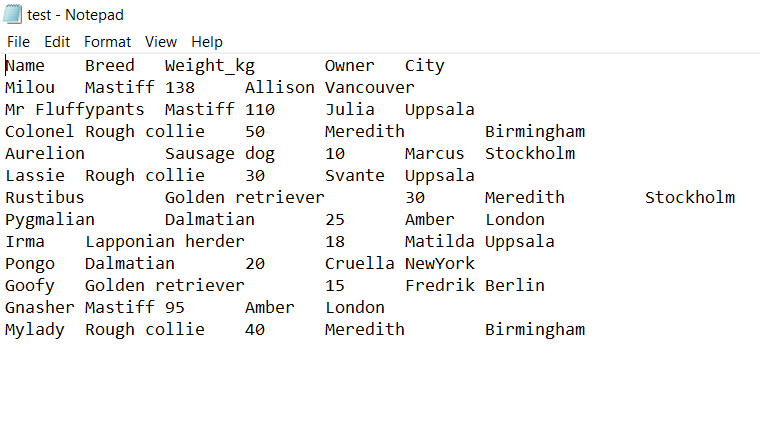

```r
write_tsv(data, 'test.txt')
```

## Exporting data and pasting to excel

[figure not shown]

```r
write_tsv(data, 'test.txt')
```

## Exporting data directly to excel

[figure not shown]

```r
library(writexl)
write_xlsx(data, 'test.xlsx')
```

## Remember to Google

Most of the time it is really easy to find answers online.

## Remember to Google

Most of the time it is really easy to find answers online.

[figure not shown]

## Remember to Google

It is expecially useful to google error messages:

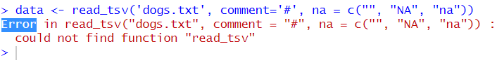

## Remember to Google

It is expecially useful to google error messages:

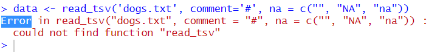

[figure not shown]

## Let’s start the exercises

Download the presentation from Teams or from:

https://github.com/mikdur/r-primer/blob/main/lecture2/Lesson2.html

[figure not shown]

If you want the original Rmarkdown version, it is available at:

https://github.com/mikdur/r-primer/blob/main/lecture2/Lesson2.Rmd

## Fun exercises

Remember to add ‘https://raw.githubusercontent.com/mikdur/r-primer/main/lecture2/’ in front of the name of the datasets.

Load the datasets, remove lines with NAs and answer the following questions:

1: Which dog breeds have only 1 representative?

2: What is the combined weight of all dalmatians present in the dataset?

3: Who is the person owning most dogs?

4: Mastiffs cannot be that big, make it so that every mastiff weighting more than 90 kg has their weight set to 75 kg.

## Actually

The AKC standard height (per their website) for this breed is 30 inches (76 cm) at the shoulder for males and 27.5 inches (70 cm) (minimum) at the shoulder for females. A typical male can weigh 150–250 pounds (68–113 kg), a typical female can weigh 120–200 pounds (54–91 kg), with very large individuals reaching 300 pounds (140 kg) or more. (https://en.wikipedia.org/wiki/English_Mastiff).

## Fungi exercises

Import **example_dataset.txt** and do the following exercises:

1: Replace NAs in the **Taxonomy** column with “Fungi”.

2: Find out the median genome size in the dataset.

3: Find out which organism has the median genome size in the dataset.

4: Find out what is the average gene number in the Fusarium species?

## FungiGenome exercises

Import **F_graminearum.gff** and do the following exercises:

1: How many genes are in the genome? On how many scaffolds are the genes located?

2: How many genes are on scaffold NC_026474.1?

3: Which scaffold has the most genes?

4: Add a column indicating the length of the genomic feature analysed on the line.

5: Which scaffold is the shortest?

6: What is the average number of exons per gene?

7: Can you export a dataset containing 1 row per gene and two columns: one with the gene ID and one with the transcript ID?

## Gff files explained

Every line shows informaton regarding a genomic **feature**, which can be a **gene**, an **mRNA**, a single **exon** or any othe unit that occupies space on the genome

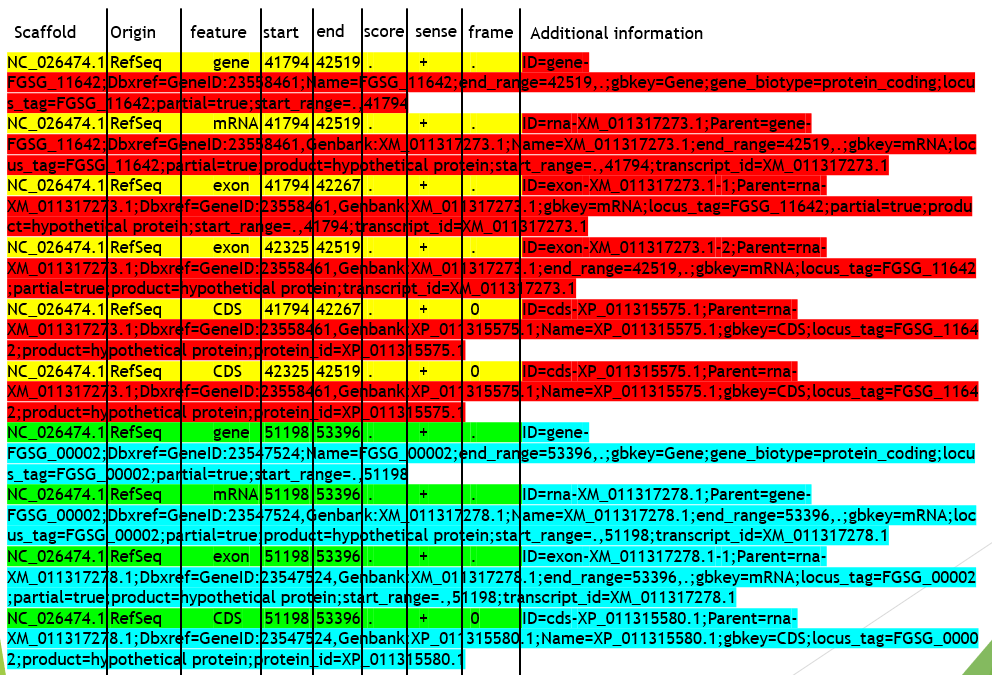